# PEC 2 — Visualización de datos (UOC)

## Terremotos USGS: Dot Density Map, Box Plot y Beeswarm Plot

Este notebook crea **tres visualizaciones** usando un **único dataset** de terremotos del USGS:

1. **Dot Density Map** — distribución espacial de epicentros.
2. **Box Plot** — distribución de magnitudes por **profundidad** y **continente**.
3. **Beeswarm Plot** — valores individuales de magnitud agrupados por **bandas de profundidad**.

```python
# Instalar versiones compatibles
!pip -q install "plotly>=6.1.1" "kaleido>=1.0.0"
```

```python
# Instalar motor de exportación para Plotly
# Ejecuta esto en una celda
import plotly, plotly.io as pio
import kaleido

print("Plotly:", plotly.__version__)
print("Kaleido ok.")
pio.renderers.default = "colab"
```

```
Plotly: 6.3.1
Kaleido ok.
```

```python
# Montar Google Drive y definir la carpeta de trabajo
from google.colab import drive
drive.mount('/content/drive')

import os

BASE_DIR = '/content/drive/MyDrive/VISUALIZACION DATOS/PEC2'
os.makedirs(BASE_DIR, exist_ok=True)

RAW_CSV = os.path.join(BASE_DIR, 'query.csv')
CLEAN_CSV = os.path.join(BASE_DIR, 'earthquakes_clean.csv')

print('Carpeta de trabajo:', BASE_DIR)
print('Esperando dataset en:', RAW_CSV)
```

```
Carpeta de trabajo: /content/drive/MyDrive/VISUALIZACION DATOS/PEC2
Esperando dataset en: /content/drive/MyDrive/VISUALIZACION DATOS/PEC2/query.csv
```

### Carga de datos

Coloca `query.csv` en la carpeta de trabajo de Drive. Si no existe, tendrás que subirlo.  
El CSV debe contener, como mínimo, las columnas: `time, latitude, longitude, depth, mag, place, id, type`.

```python
import pandas as pd
import numpy as np

# Cargar el CSV original desde Drive
df = pd.read_csv(RAW_CSV)
print(df.shape, 'filas/columnas')
df.head()
```

```
(6397, 22) filas/columnas
```

|  | time | latitude | longitude | depth | mag | magType | nst | gap | dmin | rms | ... | updated | place | type | horizontalError | depthError | magError | magNst | status | locationSource | magSource |
| --- | --- | --- | --- | --- | --- | --- | --- | --- | --- | --- | --- | --- | --- | --- | --- | --- | --- | --- | --- | --- | --- |
| 0 | 2024-12-31T23:13:20.048Z | -20.1826 | -70.6231 | 35.00 | 5.0 | mwr | 37.0 | 129.0 | 0.470 | 0.83 | ... | 2025-03-08T22:39:14.040Z | 49 km W of Puerto, Chile | earthquake | 3.29 | 1.918 | 0.061 | 26.0 | reviewed | us | us |
| 1 | 2024-12-31T22:32:02.906Z | 8.0127 | 127.2640 | 10.00 | 4.6 | mb | 45.0 | 116.0 | 1.915 | 0.61 | ... | 2025-03-08T22:39:14.040Z | 86 km ENE of Kinablangan, Philippines | earthquake | 10.20 | 1.913 | 0.091 | 36.0 | reviewed | us | us |
| 2 | 2024-12-31T20:09:41.043Z | -6.6675 | 150.5771 | 10.00 | 5.1 | mb | 61.0 | 46.0 | 2.753 | 0.74 | ... | 2025-03-08T22:39:14.040Z | 124 km ESE of Kandrian, Papua New Guinea | earthquake | 9.93 | 1.340 | 0.070 | 66.0 | reviewed | us | us |
| 3 | 2024-12-31T19:46:28.183Z | -5.1354 | 152.1814 | 60.51 | 4.6 | mb | 64.0 | 35.0 | 0.838 | 0.58 | ... | 2025-03-08T22:39:14.040Z | 88 km S of Kokopo, Papua New Guinea | earthquake | 9.16 | 5.561 | 0.084 | 42.0 | reviewed | us | us |
| 4 | 2024-12-31T19:18:38.342Z | 9.0825 | 40.0771 | 10.00 | 4.8 | mb | 89.0 | 38.0 | 1.393 | 0.80 | ... | 2025-03-08T22:39:14.040Z | 14 km NW of Āwash, Ethiopia | earthquake | 7.00 | 1.841 | 0.055 | 102.0 | reviewed | us | us |

5 rows × 22 columns

### Limpieza y creación de variables

- Convertimos `time` a `datetime`
- Corregimos profundidades negativas a 0 (si las hubiera)
- Creamos **bandas de profundidad** (`depth_bin`) con la clasificación estándar:
  - *Shallow (0–70 km)*
  - *Intermediate (70–300 km)*
  - *Deep (>300 km)*
- Extraemos `country` de `place` (heurística: último token separado por coma)
- Mapeamos `continent` a partir de `country` (diccionario incluido)

```python
import re

# Asegurar tipos
df['time'] = pd.to_datetime(df['time'], errors='coerce')

# Profundidad
df['depth'] = pd.to_numeric(df['depth'], errors='coerce').clip(lower=0)

# Magnitud
df['mag'] = pd.to_numeric(df['mag'], errors='coerce')

# Bandas de profundidad
def depth_to_bin(d):
    if pd.isna(d):
        return "Unknown"
    if d <= 70:
        return "Shallow (0–70 km)"
    elif d <= 300:
        return "Intermediate (70–300 km)"
    else:
        return "Deep (>300 km)"

df['depth_bin'] = df['depth'].apply(depth_to_bin)

# Extraer país de 'place' (heurística: último token tras coma)
def extract_country(place):
    if isinstance(place, str) and ',' in place:
        cand = place.split(',')[-1].strip()
        replacements = {
            "USA": "United States",
            "UK": "United Kingdom",
            "U.K.": "United Kingdom",
            "Türkiye": "Turkey",
            "Viet Nam": "Vietnam",
            "Russian Federation": "Russia",
            "Côte d'Ivoire": "Ivory Coast",
            "Congo": "Democratic Republic of the Congo",
            "DRC": "Democratic Republic of the Congo",
            "D.R.C.": "Democratic Republic of the Congo",
            "Timor-Leste": "East Timor",
        }
        return replacements.get(cand, cand)
    return "Unknown"

df['country'] = df['place'].apply(extract_country)

# País -> Continente
country_to_continent = {
    # Europe
    "Spain": "Europe", "France": "Europe", "Germany": "Europe", "Italy": "Europe",
    "Portugal": "Europe", "United Kingdom": "Europe", "Greece": "Europe",
    "Iceland": "Europe", "Turkey": "Europe", "Poland": "Europe", "Romania": "Europe",
    "Norway": "Europe", "Sweden": "Europe", "Finland": "Europe", "Netherlands": "Europe",
    "Belgium": "Europe", "Ireland": "Europe", "Denmark": "Europe", "Czech Republic": "Europe",
    "Austria": "Europe", "Switzerland": "Europe", "Bulgaria": "Europe", "Croatia": "Europe",
    "Albania": "Europe", "North Macedonia": "Europe", "Serbia": "Europe", "Bosnia and Herzegovina": "Europe",
    "Montenegro": "Europe", "Slovenia": "Europe", "Hungary": "Europe", "Slovakia": "Europe",
    "Lithuania": "Europe", "Latvia": "Europe", "Estonia": "Europe", "Ukraine": "Europe",
    # Americas
    "United States": "Americas", "Canada": "Americas", "Mexico": "Americas",
    "Guatemala": "Americas", "Honduras": "Americas", "El Salvador": "Americas",
    "Nicaragua": "Americas", "Costa Rica": "Americas", "Panama": "Americas",
    "Colombia": "Americas", "Venezuela": "Americas", "Ecuador": "Americas",
    "Peru": "Americas", "Bolivia": "Americas", "Chile": "Americas",
    "Argentina": "Americas", "Uruguay": "Americas", "Paraguay": "Americas",
    "Brazil": "Americas", "Haiti": "Americas", "Dominican Republic": "Americas",
    "Cuba": "Americas", "Jamaica": "Americas", "Puerto Rico": "Americas",
    "Trinidad and Tobago": "Americas",
    # Asia
    "China": "Asia", "Japan": "Asia", "South Korea": "Asia", "North Korea": "Asia",
    "India": "Asia", "Pakistan": "Asia", "Bangladesh": "Asia", "Sri Lanka": "Asia",
    "Nepal": "Asia", "Bhutan": "Asia", "Myanmar": "Asia", "Thailand": "Asia",
    "Laos": "Asia", "Vietnam": "Asia", "Cambodia": "Asia", "Malaysia": "Asia",
    "Singapore": "Asia", "Indonesia": "Asia", "Philippines": "Asia", "Brunei": "Asia",
    "Mongolia": "Asia", "Kazakhstan": "Asia", "Uzbekistan": "Asia", "Turkmenistan": "Asia",
    "Kyrgyzstan": "Asia", "Tajikistan": "Asia", "Afghanistan": "Asia", "Iran": "Asia",
    "Iraq": "Asia", "Saudi Arabia": "Asia", "United Arab Emirates": "Asia", "Qatar": "Asia",
    "Bahrain": "Asia", "Kuwait": "Asia", "Oman": "Asia", "Yemen": "Asia",
    "Israel": "Asia", "Jordan": "Asia", "Lebanon": "Asia", "Syria": "Asia",
    "Georgia": "Asia", "Armenia": "Asia", "Azerbaijan": "Asia",
    # Africa
    "Morocco": "Africa", "Algeria": "Africa", "Tunisia": "Africa", "Libya": "Africa",
    "Egypt": "Africa", "Sudan": "Africa", "South Sudan": "Africa", "Ethiopia": "Africa",
    "Eritrea": "Africa", "Djibouti": "Africa", "Somalia": "Africa", "Kenya": "Africa",
    "Tanzania": "Africa", "Uganda": "Africa", "Rwanda": "Africa", "Burundi": "Africa",
    "Democratic Republic of the Congo": "Africa", "Republic of the Congo": "Africa",
    "Gabon": "Africa", "Equatorial Guinea": "Africa", "Cameroon": "Africa",
    "Nigeria": "Africa", "Ghana": "Africa", "Ivory Coast": "Africa",
    "Senegal": "Africa", "Mali": "Africa", "Niger": "Africa", "Mauritania": "Africa",
    "Burkina Faso": "Africa", "Guinea": "Africa", "Sierra Leone": "Africa", "Liberia": "Africa",
    "Benin": "Africa", "Togo": "Africa", "Namibia": "Africa", "Botswana": "Africa",
    "Zimbabwe": "Africa", "Zambia": "Africa", "Mozambique": "Africa", "Angola": "Africa",
    "Madagascar": "Africa", "Malawi": "Africa", "Eswatini": "Africa", "Lesotho": "Africa",
    # Oceania
    "Australia": "Oceania", "New Zealand": "Oceania", "Fiji": "Oceania",
    "Papua New Guinea": "Oceania", "Samoa": "Oceania", "Tonga": "Oceania",
    "Vanuatu": "Oceania", "Solomon Islands": "Oceania", "Micronesia": "Oceania",
    "Kiribati": "Oceania",
    # Frequent territories in USGS strings
    "Greenland": "Americas", "Azores": "Europe", "Canary Islands": "Africa",
    "Guadeloupe": "Americas", "Martinique": "Americas",
    "Réunion": "Africa", "Mayotte": "Africa",
    "New Caledonia": "Oceania", "French Polynesia": "Oceania",
    "Northern Mariana Islands": "Oceania", "American Samoa": "Oceania",
    "Guam": "Oceania", "Puerto Rico": "Americas"
}

df['continent'] = df['country'].map(country_to_continent).fillna('Unknown')

# Selección de columnas de interés
cols = ['id','time','latitude','longitude','depth','depth_bin','mag','place','country','continent','type']
df_clean = df[cols].copy()

# Guardar limpio en Drive
df_clean.to_csv(CLEAN_CSV, index=False)
CLEAN_CSV
```

```
'/content/drive/MyDrive/VISUALIZACION DATOS/PEC2/earthquakes_clean.csv'
```

## Visualización 1 — Dot Density Map (mapa de puntos)

Distribución de epicentros por el mundo. Color por **magnitud**.

```python
import plotly.express as px

# Crear categorías de magnitud para color (opcional)
mag_bins = pd.cut(df_clean['mag'],
                  bins=[0, 5.0, 6.0, 7.0, 10],
                  labels=['<5.0','5.0–5.9','6.0–6.9','≥7.0'],
                  include_lowest=True)
df_clean['mag_bin'] = mag_bins.astype(str)

fig_map = px.scatter_geo(
    df_clean,
    lat='latitude',
    lon='longitude',
    hover_name='place',
    hover_data={'mag': True, 'depth': True, 'time': True, 'country': True},
    color='mag_bin',
    size_max=6,
    opacity=0.6,
    projection='natural earth',
    title='Epicentros de terremotos (USGS, último año, M≥4.5)'
)
fig_map.update_layout(legend_title_text='Magnitud')
fig_map.show()
```

[interactive chart not shown]

## Visualización 2 — Box Plot

Comparativa de **magnitud** por **banda de profundidad** y por **continente**.

```python
# Box plot por profundidad
fig_box_depth = px.box(
    df_clean,
    x='depth_bin',
    y='mag',
    points='outliers',
    title='Distribución de magnitud por banda de profundidad'
)
fig_box_depth.update_layout(xaxis_title='Banda de profundidad', yaxis_title='Magnitud')
fig_box_depth.show()

# Box plot por continente (filtrando Unknown y continentes con pocas observaciones)
continent_counts = df_clean['continent'].value_counts()
valid_continents = continent_counts[continent_counts >= 30].index  # umbral para estabilidad visual
df_box_cont = df_clean[df_clean['continent'].isin(valid_continents) & (df_clean['continent'] != 'Unknown')]

fig_box_cont = px.box(
    df_box_cont,
    x='continent',
    y='mag',
    points='outliers',
    title='Distribución de magnitud por continente (umbral ≥30 eventos)'
)
fig_box_cont.update_layout(xaxis_title='Continente', yaxis_title='Magnitud')
fig_box_cont.show()
```

[interactive chart not shown]

## Visualización 3 — Beeswarm Plot

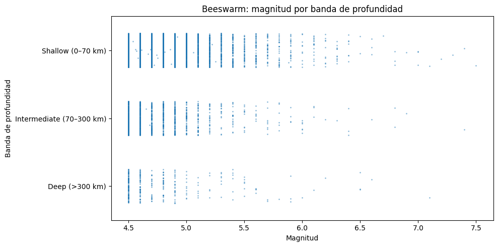

```python
# Beeswarm plot: magnitud por bandas de profundidad (sin guardar archivos)
import matplotlib.pyplot as plt
import seaborn as sns

# Orden de las bandas de profundidad
order = ['Shallow (0–70 km)', 'Intermediate (70–300 km)', 'Deep (>300 km)']

# Filtramos filas con bandas válidas y magnitud no nula
df_bee = df_clean[df_clean['depth_bin'].isin(order)].dropna(subset=['mag'])

plt.figure(figsize=(10, 5))
sns.stripplot(
    data=df_bee,
    x='mag',
    y='depth_bin',
    order=order,
    jitter=0.25,
    alpha=0.5,
    size=2
)
plt.title('Beeswarm: magnitud por banda de profundidad')
plt.xlabel('Magnitud')
plt.ylabel('Banda de profundidad')
plt.tight_layout()
plt.show()
```